# Introductory practical on data analysis with R: the algae genotyping data

## Let’s dive in the flagstat QC results

To approach this data ‘step-by-step’, we first just want to plot the mapping rate `mapped %`. For that, we will `filter()` the `statsRatios` table to keep only the records belonging “mapped %” `category`. Let’s call the resulting table `mapRatios`. 🤔

**💭 **Check the answer** 🪂**

```r
mapRatios <- statsRatios[statsRatios$category == "mapped %", ]
head(mapRatios)
##     passed failed category strainId
## 8    96.40     NA mapped %     1613
## 28   91.04     NA mapped %     1868
## 48   71.15     NA mapped %     4752
## 68   86.85     NA mapped %     5417
## 88   70.24     NA mapped %      685
## 108  38.18     NA mapped %      716
```

So now, we can plot the percentages (`passed` column) as y-values and the strain ids as x-values (aesthetics) and further add a `geom_col()` geom. Let’s plot it! 🤔

**💭 **Check the answer** 🪂**

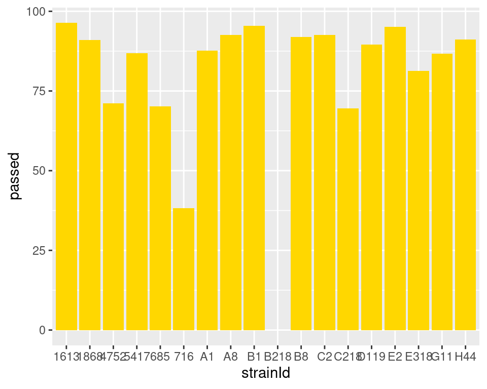

```r
mapRatioP <- ggplot(data = mapRatios,
       mapping = aes(x = strainId, y = passed)) +
  geom_col(fill = "gold")
mapRatioP
## Warning: Removed 1 row containing missing values or values outside the scale range
## (`geom_col()`).
```

**ImportantWhat do we learn from this regarding strains B218, 716, 685, …? 🤔**

So this is not too bad but, the texts of the strain ids on the x-axis tend to overlap which is ugly. We could surely increase the overall width of the graph but this would take up space unnecessarily. Instaed, we can tweak the ggplot2 `theme()` parameters as such:

**💭 **Check the answer** 🪂**

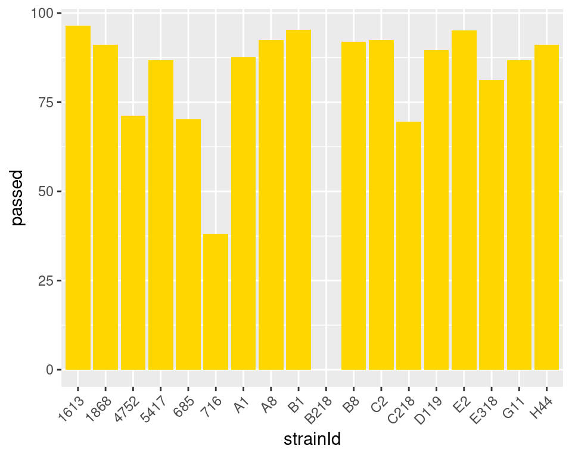

```r
mapRatioP <- mapRatioP +
  theme(axis.text.x = element_text(hjust = 1, vjust = 1, angle = 45))
mapRatioP
## Warning: Removed 1 row containing missing values or values outside the scale range
## (`geom_col()`).
```

So we learnt already something regarding the mapping step but the statsRatios table contains far more info. Ideally, we would like to inspect **everything** to have a complete picture.

There are several ways to represent this. One is by adding a color aesthetic based on category and specifying a special position in `geom_col()`

**💭 !! Check the answer !! 🪂**

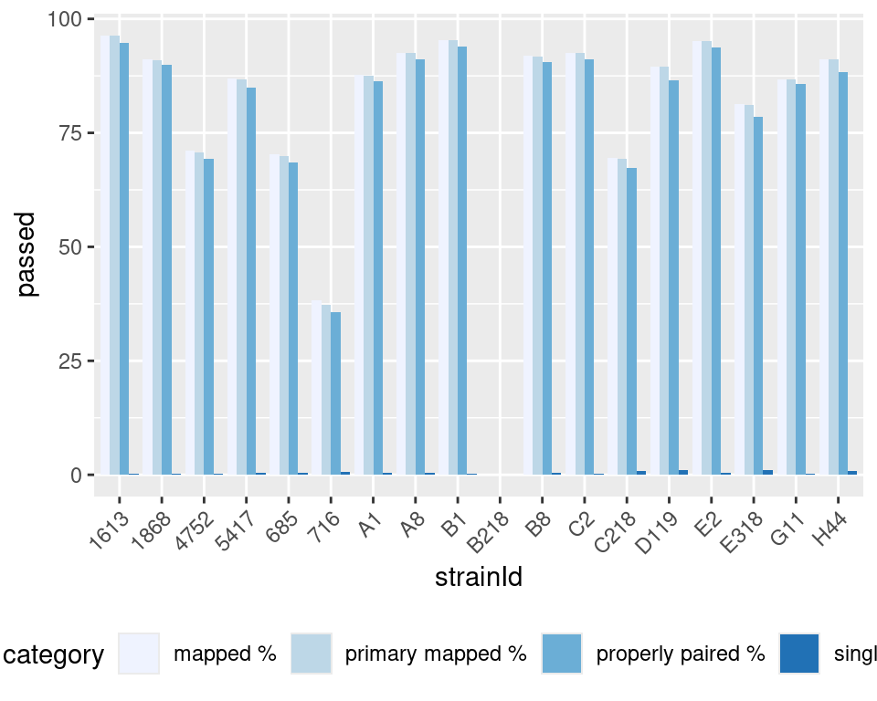

```r
statsRatiosP <-  ggplot(data=  statsRatios, mapping = aes(x = strainId, y = passed, fill = category)) +  geom_col(position = position_dodge()) +
  scale_fill_brewer(direction = 1) +
  theme(axis.text.x = element_text(hjust = 1, vjust = 1, angle = 45),
        legend.position = "bottom")
statsRatiosP
## Warning: Removed 4 rows containing missing values or values outside the scale range
## (`geom_col()`).
```

## Pivoting and exporting the flagstat data

For your non-bioinformaticians colleague to read the data, it would be far more convenient to “[pivot](https://tidyr.tidyverse.org/articles/pivot.html)” this dataframe from a ‘long’ format to a ‘wide’ one. We would like to have the values of the `category` column as separate columns (see the result below). For each strain (one row) the values from the `passed` column are pivoted to their cognate category. Furthermore, we sort the records in the table based on the strain id. The resulting `statsRatiosWide` table is displayed in html.

Can you try to figure out how to do that with `tidyr::pivot_wider()`? 🤔

**💭 **Check the answer** 🪂**

```r
statsRatiosWide <- tidyr::pivot_wider(
  statsRatios,
  id_cols=strainId,
  names_from = category,
  values_from = passed
)

statsRatiosWide <- statsRatiosWide[order(statsRatiosWide$strainId), ]

rmarkdown::paged_table(statsRatiosWide, options = list(cols.min.print = 4))
```

| strainId | mapped % | primary mapped % | properly paired % | singletons % |
| --- | --- | --- | --- | --- |
| 1613 | 96.40 | 96.35 | 94.64 | 0.31 |
| 1868 | 91.04 | 90.95 | 89.97 | 0.14 |
| 4752 | 71.15 | 70.75 | 69.31 | 0.33 |
| 5417 | 86.85 | 86.63 | 85.02 | 0.39 |
| 685 | 70.24 | 69.90 | 68.50 | 0.34 |
| 716 | 38.18 | 37.25 | 35.74 | 0.72 |
| A1 | 87.66 | 87.62 | 86.25 | 0.45 |
| A8 | 92.51 | 92.44 | 91.08 | 0.40 |
| B1 | 95.36 | 95.32 | 93.96 | 0.26 |
| B218 | NA | NA | NA | NA |

[output cut: 8 more lines]

Finally, after so much troubles parsing the “flagstats” data, we would like to save the primary data `flagstatsClean` and the resulting `statsRatiosWide` tables as tsv files for subsequent scrutiny by other colleagues in the `outDir`. Can you do that with `write.table` ? 🤔

**💭 **Check the answer** 🪂**

```r
write.table(flagstatsClean, file = file.path(outDir, "algea_flagstats.tsv"), sep = "\t", quote = FALSE, col.names = TRUE, row.names = FALSE)

write.table(statsRatiosWide, file = file.path(outDir, "algea_flagstats_summary.tsv"), sep = "\t", quote = FALSE, col.names = TRUE, row.names = FALSE)
```

# Examining the infered genetic diversity

## Loading the vcf file data and extract a SNP matrix

```r
# Take a look at the files
list.files(dataDir, recursive = TRUE)

vcfData <- read.vcfR(file.path(dataDir, "coding_data_CIBIG25/all_samples.vcf.gz"), verbose = FALSE)

glight <- vcfR2genlight(vcfData)
saveRDS(glight, file = file.path(outDir, "genotypes_genlight.rds"))
```

## Run a PCA with genotypes data and plot the infered genetic diversity

The analysis workflow on this section is in large part inspired from the material provided by the Niklaus J. Grünwald lab in [Population genetics and genomics in R](https://grunwaldlab.github.io/Population_Genetics_in_R/index.html)

Just like with any topic in R and other programming languages, there are tons of other options to conduct this type of analysis. For example [`pegas`](https://emmanuelparadis.github.io/pegas.html) is another R package dedicated to population genetic analysis.

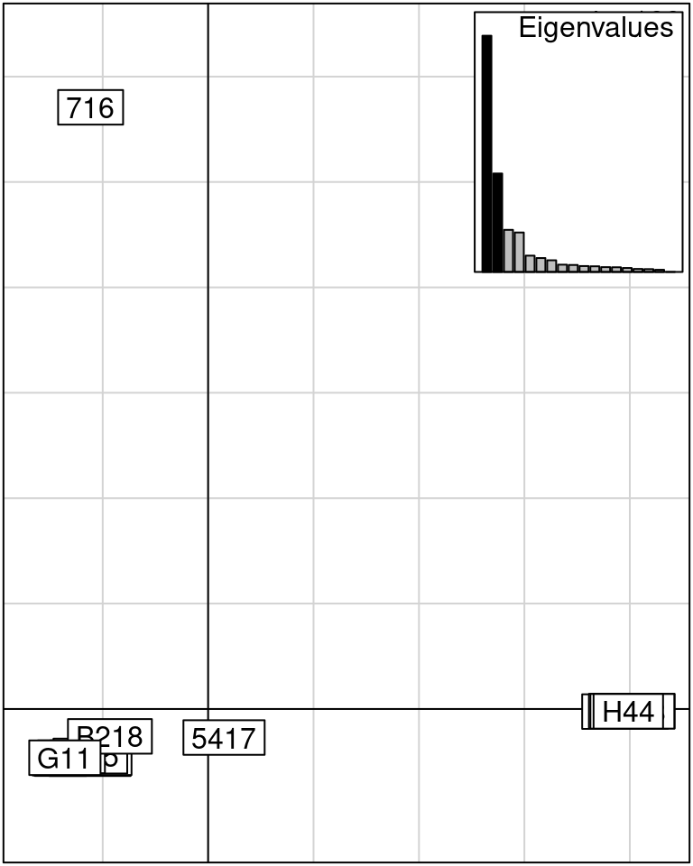

Genotypes in the PCA subspace

```r
if (!exists("glight")) glight <- readRDS(file.path(dataDir, "/coding_data_CIBIG25/genotypes_genlight.rds"))
nInd(glight)
## [1] 18
nLoc(glight)
## [1] 1375890
pca1 <- glPca(glight, nf = 20, parallel = TRUE, n.cores = 6)
print(pca1)
##  === PCA of genlight object ===
## Class: list of type glPca
## Call ($call):glPca(x = glight, nf = 20, parallel = TRUE, n.cores = 6)
##
## Eigenvalues ($eig):
##  46781.29 19490.28 8333.119 7812.193 3221.12 2752.782 ...
##
## Principal components ($scores):
##  matrix with 18 rows (individuals) and 18 columns (axes)
##
## Principal axes ($loadings):
##  matrix with 1375890 rows (SNPs) and 18 columns (axes)

scatter(pca1, posi="topright")
```

The reason we picked `glPca()` is because it is specialized for genotyping data. If you want to learn more about PCA in R, we advise you to examine specialized resources describing how to do statistical analysis with R using best practices. Here are a few resources as a starter:

- [The Handbook of Biological Statistics](https://rcompanion.org/rcompanion)
- [datacamp](https://www.datacamp.com/doc/r/anova)

## Revisiting the PCA results with ggplot2 plots

While the resulting plot is OK in preliminary stages. It is not entirely satisfactory because:

- It is difficult to overlay strains metadata which would be useful to fully grasp the output.
- stains labels are plotted on top of each others which hides part of the information.

Let’s try to come up with our own plots with `ggplot2`.

### Metadata fixing and matching

First, it is time to include the strains metadata to this dataframe so that we can plot the samples along with their characteristics (sampling site, species …).

For that we need two objects: the **metadata** (`algeaInfo`) object and the **PCA** (`pca1`)object.

The Principal components matrix, the`scores` element from the `pca1` object (list) are stored in `pca1$scores`

**💭 **Check the answer** 🪂**

```r
pcaScores <- as.data.frame(pca1$scores)
```

In this object the strain id are stored in the rownames, that are accessible using the rownames() function.

How would you create a strainId column with this information ?

**💭 **Check the answer** 🪂**

```r
rownames(pcaScores)
##  [1] "1613" "1868" "4752" "5417" "685"  "716"  "A1"   "A8"   "B1"   "B218"
## [11] "B8"   "C218" "C2"   "D119" "E2"   "E318" "G11"  "H44"
pcaScores$strainId <- rownames(pcaScores)
```

The `strainId` column contains the information about the algae strain but we need to extract it to match values in `algeaInfo`:

At this point, it may be a good idea to verify that strain IDs in both tables match, right? We could do that with set operations (`?union`). 🤔

**💭 **Check the answer** 🪂**

```r
pcaScores$strainId
##  [1] "1613" "1868" "4752" "5417" "685"  "716"  "A1"   "A8"   "B1"   "B218"
## [11] "B8"   "C218" "C2"   "D119" "E2"   "E318" "G11"  "H44"
algeaInfo$`Strain ID`
##  [1] "A818"    "B218"    "B518"    "C218"    "E318"    "H718"    "D119"
##  [8] "H44"     "A727"    "A827"    "RCC5417" "RCC1613" "RCC685"  "RCC1615"
## [15] "RCC1868" "RCC4222" "G11"     "C2"      "G2"      "E2"      "A8"
## [22] "B8"      "A1"      "G8"      "C3"      "G5"      "RCC4752" "RCC716"

pcaScores$strainId %in% algeaInfo$`Strain ID`
##  [1] FALSE FALSE FALSE FALSE FALSE FALSE  TRUE  TRUE FALSE  TRUE  TRUE  TRUE
## [13]  TRUE  TRUE  TRUE  TRUE  TRUE  TRUE
```

So it looks like the **“RCC” prefix got striped out** somehow in the read mapping data… We will **fix that.**

So first, we will modify the ids in this table (*note that it is usually better to conduct reformatting of this kind of essential metadata table, right after loading into R in order to have a consistent object across the analysis*). 🤔

**TipYou can create a new `strainId` column filled with the result of substituting `"RCC"` in the strain ids `Strain ID` with `""` using `gsub()`**

**💭 **Check the answer** 🪂**

```r
algeaInfo$strainId <- gsub("RCC", "", algeaInfo$`Strain ID`)
algeaInfo$`Strain ID` <- NULL

algeaInfo
##            Species Latitude(North) Longitude(East) Depth(m)    Sampling site
## 1      B. prasinos           78.12          -74.36        0 Baffin bay DE310
## 2      B. prasinos           78.12          -74.36        0 Baffin bay DE310
## 3      B. prasinos           78.12          -74.36        0 Baffin bay DE310
## 4      B. prasinos           78.12          -74.36        0 Baffin bay DE310
## 5      B. prasinos           78.12          -74.36        0 Baffin bay DE310
## 6      B. prasinos           78.12          -74.36        0 Baffin bay DE310
## 7      B. prasinos           78.12          -74.36        0 Baffin bay DE310
## 8      B. prasinos           76.03          -77.23        0 Baffin bay DE110
## 9      B. prasinos           75.95          -85.58       20 Baffin bay DE410
## 10     B. prasinos           75.95          -85.58       20 Baffin bay DE410
## 11     B. prasinos           67.48          -63.78        0    Baffin Island
## 12     B. prasinos           57.57            8.67       35        North Sea
## 13     B. prasinos           54.18          45,176        0        North Sea
## 14     B. prasinos           50.20            0.32       10  English Channel
## 15     B. prasinos           48.75           -3.95        0  English Channel
## 16     B. prasinos           42.48            3.53        3      Banyuls bay
## 17     B. prasinos           42.48            3.53        3      Banyuls bay
## 18     B. prasinos           42.48            3.53        3      Banyuls bay
## 19     B. prasinos           42.48            3.53        3      Banyuls bay
## 20     B. prasinos           42.48            3.53        3      Banyuls bay
## 21     B. prasinos           42.48            3.53        3      Banyuls bay
## 22     B. prasinos           42.48            3.53        3      Banyuls bay
## 23     B. prasinos           42.48            3.53        3      Banyuls bay
## 24 Bathycoccus sp.           42.48            3.53        3      Banyuls bay
## 25 Bathycoccus sp.           42.48            3.53        3      Banyuls bay
## 26 Bathycoccus sp.           42.48            3.53        3      Banyuls bay
## 27     B. prasinos           40.48           14.14      100   Gulf of Naples
## 28      B. calidus          -14.48          113.45       70     Indian Ocean
##    Sampling date Sample source strainId
## 1     16/10/2021      DarkEdge     A818
## 2     16/10/2021      DarkEdge     B218
## 3     16/10/2021      DarkEdge     B518
## 4     16/10/2021      DarkEdge     C218
## 5     16/10/2021      DarkEdge     E318
## 6     16/10/2021      DarkEdge     H718
## 7     16/10/2021      DarkEdge     D119
## 8     12/10/2021      DarkEdge      H44
## 9     21/10/2021      DarkEdge     A727
## 10    21/10/2021      DarkEdge     A827
## 11    01/06/2016           RCC     5417
## 12    26/07/2007           RCC     1613
## 13    16/05/2001           RCC      685
## 14    08/07/2007           RCC     1615
## 15    05/02/2009           RCC     1868
## 16    01/01/2006           RCC     4222
## 17    03/12/2018           OOB      G11
## 18    28/01/2019           OOB       C2
## 19    11/02/2019           OOB       G2
## 20    25/02/2019           OOB       E2
## 21    26/02/2019           OOB       A8
## 22    26/02/2019           OOB       B8
## 23    19/03/2019           OOB       A1
## 24    03/12/2018           OOB       G8
## 25    12/12/2018           OOB       C3
## 26    12/12/2018           OOB       G5
## 27    17/04/1986           RCC     4752
## 28    11/06/2003           RCC      716
```

Now we want to join the two dataframes.

can use `dplyr` join functions (type `?"mutate-joins"` in the console). We will perform a `left_join` to bring strains info into the `pcaScores` tibble. The join will be done on the `strainId` key column that provides the ‘bridging’ information. 🤔

**💭 **Check the answer** 🪂**

```r
pcaScores <- left_join(x = pcaScores,
                       y = algeaInfo,
                       by = join_by("strainId" == "strainId")
                       )
pcaScores
##           PC1        PC2        PC3         PC4           PC5          PC6
## 1  -112.03184 -47.183807 110.172749 -161.141297  101.15917300   28.6936884
## 2  -127.84273 -46.716350 -13.233150  -30.527627  -54.59520508  -20.8012080
## 3  -111.16199 -46.250979 104.979524 -152.576989   87.63179214   22.5440515
## 4    15.10582 -27.079454 282.122210  239.527414    3.16295679   -0.3738379
## 5  -107.54654 -44.848370  85.784808 -122.927996 -128.31955841 -138.1869568
## 6  -111.46472 570.839422  -1.973938   -4.200555    0.59818865   -0.1780703
## 7  -138.79138 -46.503655 -83.342612   55.515617   24.28082663  -11.1275262
## 8  -137.40232 -46.339488 -71.514900   41.924370   11.16358961   -3.3719248
## 9  -122.29413 -44.581395   8.001766  -36.349710 -132.25879108  165.4595526
## 10  -93.15002 -26.037039  -9.256487    5.555510   -0.61105270   -0.7215386
## 11 -136.82960 -46.313158 -69.142024   39.232680    1.80094025   11.8239963
## 12  395.47045  -2.484109 -23.409031   -9.810497    1.41920167    0.2197795
## 13 -139.16249 -46.625531 -83.724431   56.673119   26.36438214  -16.7960827
## 14  401.86192  -2.053202 -24.737433  -11.871130    0.33863102    0.5348833
## 15 -139.89259 -47.131945 -84.369088   52.857105   23.95332195  -14.8736373
## 16  402.41853  -2.235076 -24.228190  -11.854792    0.03435968    0.4309737
## 17 -135.86876 -46.247874 -79.574680   60.874698   33.60823930  -23.1029159
## 18  398.58240  -2.207988 -22.555091  -10.899921    0.26900443   -0.1732269
##             PC7          PC8          PC9         PC10        PC11        PC12
## 1     2.4324374    4.3755181  107.0423916  -0.26153035  -0.1750335  -1.3722734
## 2  -187.2949606    4.8266294    2.5067562  -0.49766986   0.1778960   2.8225143
## 3     0.6696049   -3.3459450 -115.3065381   0.81724446   0.5517485   0.4153547
## 4    -4.4537228   -1.1849181    0.6856822   0.97658807   0.3510400  -1.5154552
## 5    62.2496533    1.1339156    3.9956881   0.33318967   0.9516276   0.1345464
## 6    -0.2817523    0.1115617    0.2147752   0.03704459  -0.0775481  -0.0605847
## 7    19.7366960   25.7848410   -0.1497884  -3.45104790  -3.0377617  25.3056956
## 8    11.5493349 -102.6953461    3.2095837 -23.07194096 -89.4102768 -19.4539874
## 9    33.3632292   22.8979432    0.1223425  -2.47532932  -9.2341444  -0.8615749
## 10    2.9047916   -1.9788640   -3.3376697   0.48596634   3.3255517   0.5712786
## 11   15.2249208  -86.6959709    4.3590895  22.89319546  95.5272261  33.5546920
## 12    0.5689388    0.2307330    0.2242105 -85.23810080  15.2462832  26.3505927
## 13   13.2448904   42.7399627   -1.1263022   8.94316732  18.2220216 -47.6499353
## 14   -0.2939681   -0.7884739    0.5423431  70.24236693 -18.3476939   6.8480572
## 15   13.6599750   33.3557500   -1.4064254   8.46596452  13.9571778 -67.8598262
## 16   -0.2360015   -0.7523719    0.5382051  66.90748109 -17.9536803   6.0566675
## 17   17.0693589   60.7251808   -1.1694334 -11.57236277 -31.3780094  76.1637322
## 18   -0.1134258    1.2598544   -0.9449104 -53.53422649  21.3035757 -39.4494941
##            PC13         PC14         PC15        PC16          PC17
## 1    0.05866961   0.20562571  -0.09456401  -4.3629273  -0.033094372
## 2    0.65197138   1.91355048   0.04662667  -6.2269444  -0.065206339
## 3   -0.49649125   0.15209798   0.04203922  -7.6041289  -0.052462605
## 4   -0.75207542   0.85821279  -0.30958680  -4.9236260  -0.103969560
## 5   -0.42174481   0.23718354   0.08190374  -7.0298565  -0.144406301
## 6   -0.04488193  -0.02881098  -0.14518082  -2.6237634  -0.002934407
## 7    7.64834971  97.05132698  28.47168875 -10.3425259  -0.173915232
## 8   -0.54266515  -7.89518941   3.30958107  -7.5366464  -0.184659854
## 9    0.18614317  -2.29398041  -0.37275958  -7.0457563  -0.107864860
## 10   0.61782143   1.24389083   3.64775461  96.1137798   0.979196370
## 11   7.23340790 -12.16913781  -6.96985250 -10.4681988   0.080857335
## 12 -76.55650552  -2.30937177  -0.50443998  -1.1554007  -0.354268594
## 13 -19.30484496 -46.56875496  66.30965229 -10.2652671   0.351146315
## 14  -8.21858045   0.28842994   0.39611741  -0.3188799 -60.758238446
## 15 -27.13883844  12.78081096 -68.79648189  -5.9142822  -0.328887499
## 16  -6.65353970   0.79100203  -0.34918433  -1.9391169  62.224499683
## 17  32.72949975 -45.42156558 -25.07053343  -6.5936014  -0.102796747
## 18  91.00430466   1.16467969   0.30721958  -1.7628580  -1.222994886
##             PC18 strainId     Species Latitude(North) Longitude(East) Depth(m)
## 1  -0.0001177341     1613 B. prasinos           57.57            8.67       35
## 2  -0.0001177341     1868 B. prasinos           48.75           -3.95        0
## 3  -0.0001177341     4752 B. prasinos           40.48           14.14      100
## 4  -0.0001177341     5417 B. prasinos           67.48          -63.78        0
## 5  -0.0001177341      685 B. prasinos           54.18          45,176        0
## 6  -0.0001177341      716  B. calidus          -14.48          113.45       70
## 7  -0.0001177341       A1 B. prasinos           42.48            3.53        3
## 8  -0.0001177341       A8 B. prasinos           42.48            3.53        3
## 9  -0.0001177341       B1        <NA>              NA            <NA>       NA
## 10 -0.0001177341     B218 B. prasinos           78.12          -74.36        0
## 11 -0.0001177341       B8 B. prasinos           42.48            3.53        3
## 12 -0.0001177341     C218 B. prasinos           78.12          -74.36        0
## 13 -0.0001177341       C2 B. prasinos           42.48            3.53        3
## 14 -0.0001177341     D119 B. prasinos           78.12          -74.36        0
## 15 -0.0001177341       E2 B. prasinos           42.48            3.53        3
## 16 -0.0001177341     E318 B. prasinos           78.12          -74.36        0
## 17 -0.0001177341      G11 B. prasinos           42.48            3.53        3
## 18 -0.0001177341      H44 B. prasinos           76.03          -77.23        0
##       Sampling site Sampling date Sample source
## 1         North Sea    26/07/2007           RCC
## 2   English Channel    05/02/2009           RCC
## 3    Gulf of Naples    17/04/1986           RCC
## 4     Baffin Island    01/06/2016           RCC
## 5         North Sea    16/05/2001           RCC
## 6      Indian Ocean    11/06/2003           RCC
## 7       Banyuls bay    19/03/2019           OOB
## 8       Banyuls bay    26/02/2019           OOB
## 9              <NA>          <NA>          <NA>
## 10 Baffin bay DE310    16/10/2021      DarkEdge
## 11      Banyuls bay    26/02/2019           OOB
## 12 Baffin bay DE310    16/10/2021      DarkEdge
## 13      Banyuls bay    28/01/2019           OOB
## 14 Baffin bay DE310    16/10/2021      DarkEdge
## 15      Banyuls bay    25/02/2019           OOB
## 16 Baffin bay DE310    16/10/2021      DarkEdge
## 17      Banyuls bay    03/12/2018           OOB
## 18 Baffin bay DE110    12/10/2021      DarkEdge
```

**ImportantAre all strains included in the genotyping described in the strains metadata table `algeaInfo`? 🤔**

We should now have the required info in order to generate an informative plot. We start with a base `ggplot2` plot assigned to the `pp` variable :

- We represent the position of the strains in the PC space using the first and second PCs as points (`geom_point()`).
- The `shape` aesthetic will be mapped to values in the `Species` column.
- The `color` aesthetic will be mapped to values in the `Sampling site` column
- Point `size` should be = 5 and transparency increased with `alpha` set to 0.3

**💭 **Check the answer** 🪂**

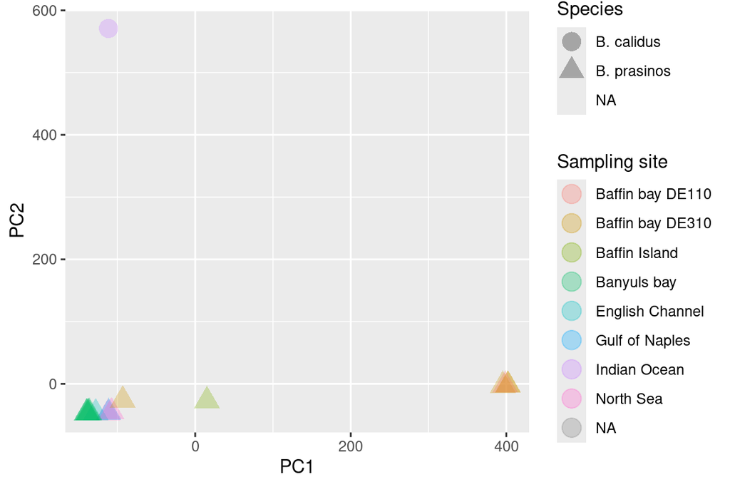

```r
pp <- ggplot(data = pcaScores,
             mapping =  aes(x = PC1,
                            y= PC2,
                            shape = Species,
                            color = `Sampling site`)
             ) +
  geom_point(size = 5, alpha = 0.3)
pp
## Warning: Removed 1 row containing missing values or values outside the scale range
## (`geom_point()`).
```

So now we are in a much better position to interpret the graph.

**NoteThe strain belonging to the *B. calidus* species is isolated, consistent with an expected more distant relatedness with strains from the *B. prasinos* species. This is captured by PC2.**

**NoteStrains collected in the Baffin area tend to separate from the others. This is captured by PC1.**

It would be nice to add strain ids in this plot. For that, let’s add some space around the data points in `pp` and modify the limits of the plot axis with `xlim` and `ylim`. Minimum x should be -250 and minmum y should be -150. We will also add an informative title. 🤔

**💭 **Check the answer** 🪂**

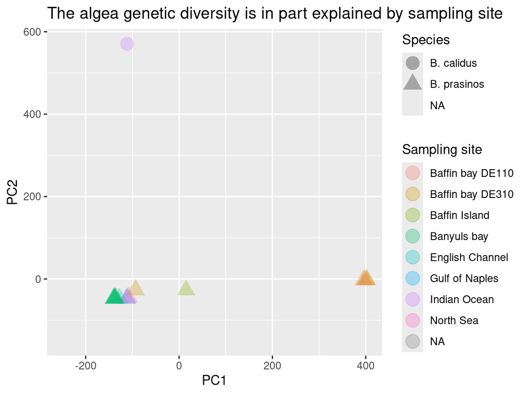

```r
pp <- pp +
  xlim(-250, NA) + ylim(-150, NA) +
  labs(title = "The algea genetic diversity is in part explained by sampling site")
pp
## Warning: Removed 1 row containing missing values or values outside the scale range
## (`geom_point()`).
```

To include strain ids as labels, we will add a text geom from the `ggrepel` package and tweak the parameters to force plotting of all overlapping labels.

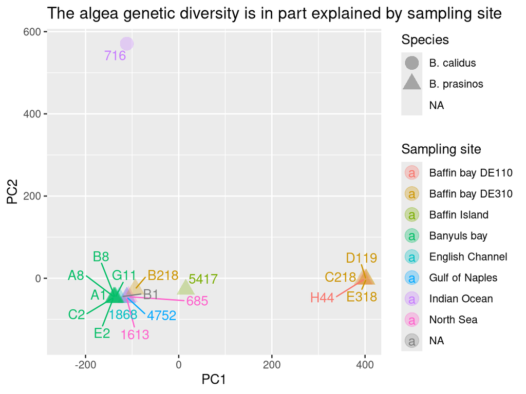

```r
pp <- pp +
  ggrepel::geom_text_repel(mapping = aes(label = strainId),
                           force = 20,
                           max.overlaps = 30)
pp
## Warning: Removed 1 row containing missing values or values outside the scale range
## (`geom_point()`).
```

This looks nice but lets use a more sober `theme` that is suitable for publications, like `theme_light()` 🤔

**💭 **Check the answer** 🪂**

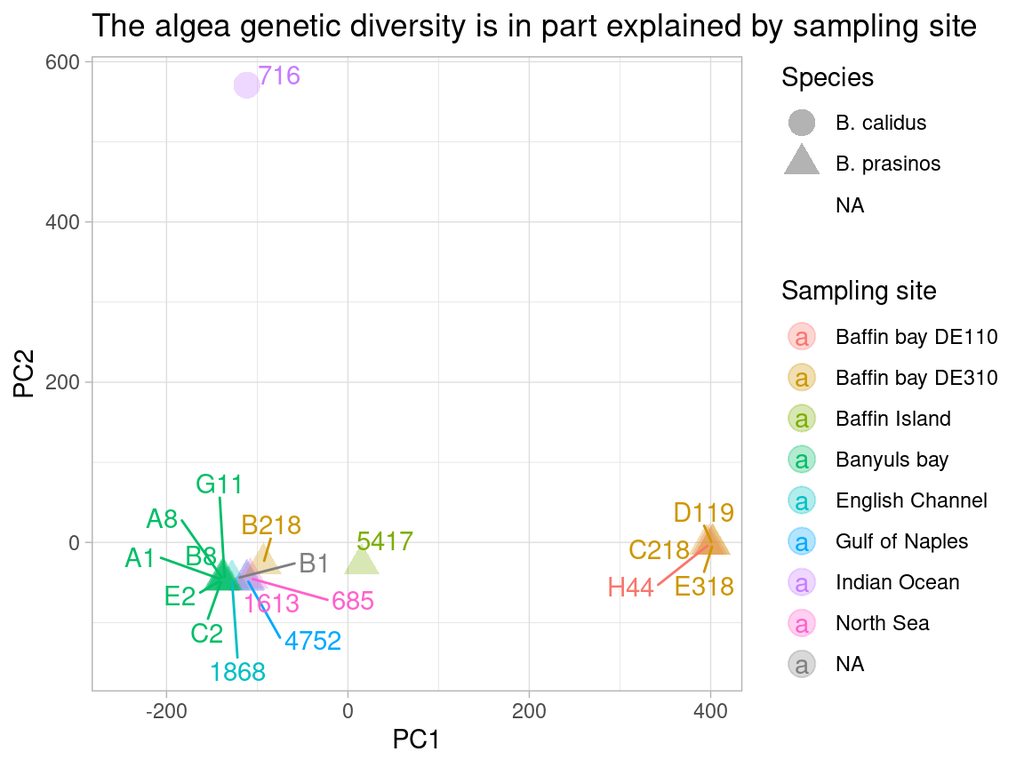

```r
pp <- pp +
  theme_light()
pp
## Warning: Removed 1 row containing missing values or values outside the scale range
## (`geom_point()`).
```

We are perfectionists and clearly the values and ticks in the context of a PCA do not make much sense. We would like to avoid plotting them but we do not know how to tweak the plot to do that…

**TipMay be we could ask an LLM like Chat GPT or Gemini. Can you figure out what prompts to use ?🤔**

**💭 **Check the answer** 🪂**

```r
glue::glue("
*** Prompt1 ***
Hi,
Here is the code of a ggplot2 plot:
pp <- pp +
  ggrepel::geom_text_repel(mapping = aes(label = strainId),
                           force = 20,
                           max.overlaps = 30)
pp

*** Prompt2 ***
How can I avoid plotting the scales on the axis (numbers and tick marks)?
")
```

Let’s implement the solution suggested by the LLM:

**💭 **Check the answer** 🪂**

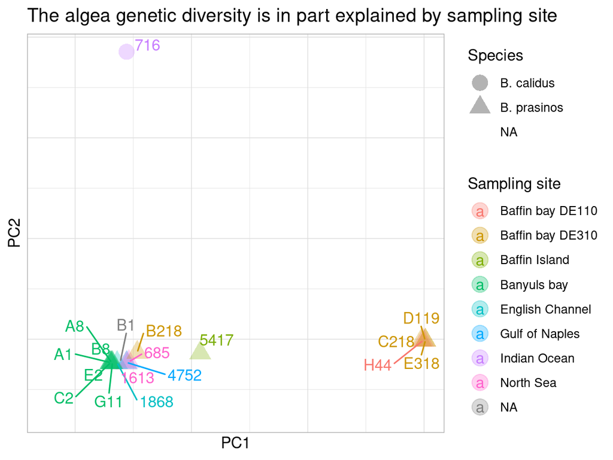

```r
pp <- pp +
    theme(axis.text =  element_blank(),
        axis.ticks = element_blank())
pp
## Warning: Removed 1 row containing missing values or values outside the scale range
## (`geom_point()`).
```

# Make a composite plot as a final wrap up

Now let’s imagine we would like to make a composite plot of our best graphics to use as a Figure in a manuscript.

In R there are several packages that enables to do that. To name the main ones: - [patchwork](https://patchwork.data-imaginist.com/index.html) makes it ridiculously simple to combine separate ggplots into the same graphic. - [cowplot](https://wilkelab.org/cowplot/index.html) helps with creating publication-quality figures, such as a set of themes, functions to align plots and arrange them into complex compound figures - [aplot](https://yulab-smu.top/pkgdocs/aplot.html) by the creator of amazing packages for phylogenetic trees plotting or complex heatmaps. This is our favorite because it works very well with these kind of atypical plots…

Let’s pick `pp` and `statsRatiosP` plots and plot them together in a plot named `compoPlot`. With the `cowplot::plot_grid()`, this is pretty easy… 🤔

**💭 **Check the answer** 🪂**

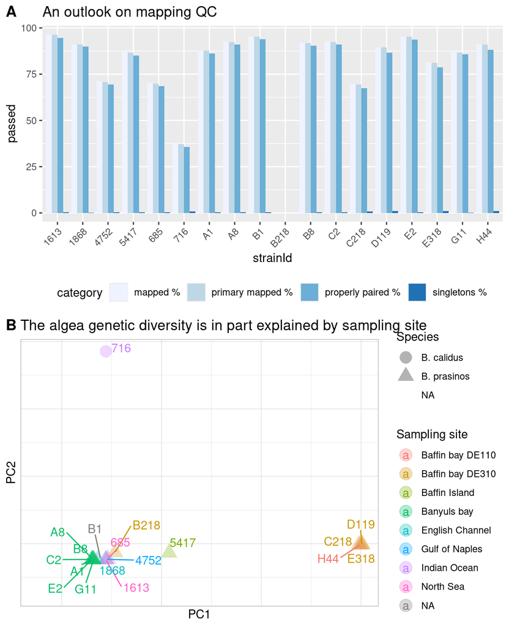

```r
compoPlot <- cowplot::plot_grid(statsRatiosP + ggtitle("An outlook on mapping QC"),
                                pp,
                                labels = c('A', 'B'), ncol = 1)
## Warning: Removed 4 rows containing missing values or values outside the scale range
## (`geom_col()`).
## Warning: Removed 1 row containing missing values or values outside the scale range
## (`geom_point()`).
compoPlot
```

**Important**

BTW, do you now have an hypothesis for the reason why only a limited fraction of the, say “716” strains reads, mapped to the reference? 🤔

OK, great but for the manuscript we would like to have a separate image file in the pdf format. Because `compoPlot` is a ggplot object. We can use a the dedicated `ggplot2` function for this task.

**💭 **Check the answer** 🪂**

```r
ggsave(filename = file.path(outDir, "composite_plot.pdf"),
       plot = compoPlot,
       width = 6.5, height = 8, units = "in", dpi = 300)
```

# Bonus: Distance tree of the samples

In biology, trees are a common way of representing the relationships between a diversity of samples.

Using the `ape` package, commonly used in phylogenetics and evolution, we will build a phenetic tree (distance-based from SNP data). Be careful, it’s not a model-based phylogeny !

**💭 **Check the answer** 🪂**

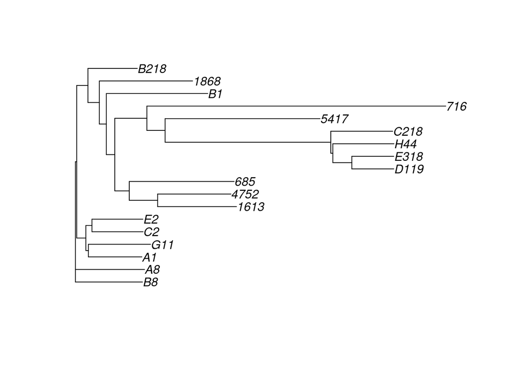

```r
# genetic distances (e.g., Euclidean on genlight)
Distances <- dist(glight)

# Neighbor-Joining tree
distance_tree <- nj(Distances)

# distance_tree is a "phylo" object
plot(distance_tree)
```

**Important**

The orientation of the resulting tree is arbitrary. How would you orient it now that we know a little bit more about the diversity of our samples ? 🤔

**💭 **Check the answer** 🪂**

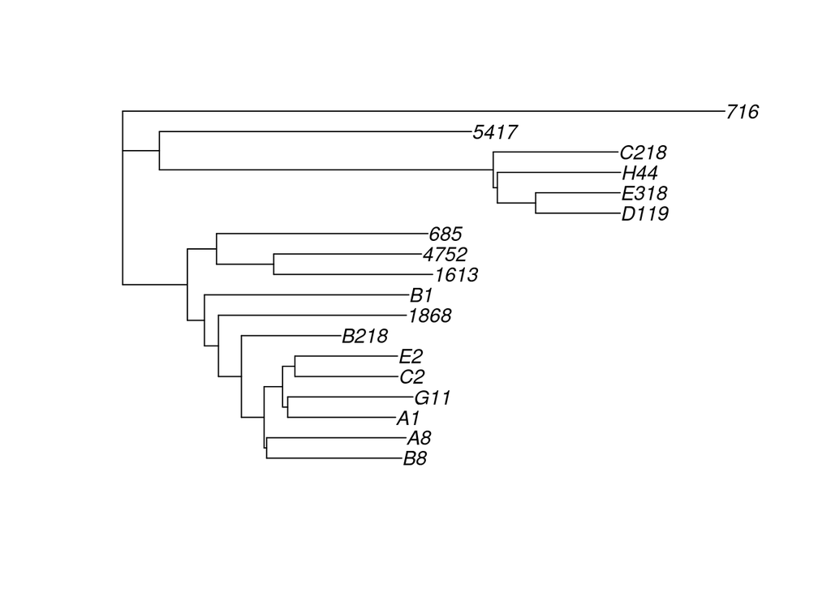

```r
# Rooting the tree
rooted_tree <- root(distance_tree, "716")

# ploting the tree again
plot(rooted_tree)
```

In the same manner as for the PCA, it’s best to plot the phylogeny with some more information that we can get from the metadata table.1

**💭 **Check the answer** 🪂**

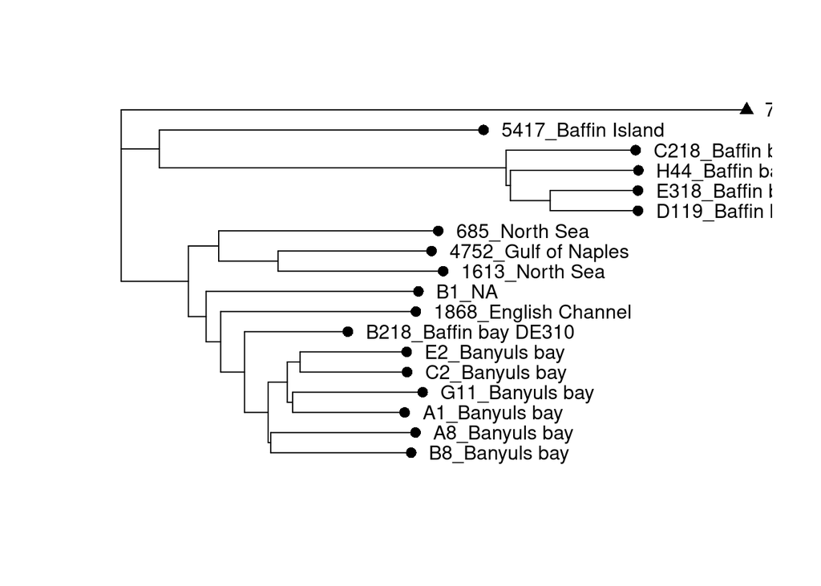

```r
# Where are the tip labels stored ?
str(rooted_tree)
## List of 4
##  $ edge       : int [1:33, 1:2] 19 28 27 26 25 21 20 20 21 22 ...
##  $ edge.length: num [1:33] 94.2 24.8 20.4 33.4 33 ...
##  $ tip.label  : chr [1:18] "1613" "1868" "4752" "5417" ...
##  $ Nnode      : int 16
##  - attr(*, "class")= chr "phylo"
##  - attr(*, "order")= chr "cladewise"

tips <- rooted_tree$tip.label

# what does the below return ?
match(rooted_tree$tip.label,algeaInfo$strainId)
##  [1] 12 15 27 11 13 28 23 21 NA  2 22  4 18  7 20  5 17  8

# the "species" column from the metadata table
algeaInfo$Species
##  [1] "B. prasinos"     "B. prasinos"     "B. prasinos"     "B. prasinos"
##  [5] "B. prasinos"     "B. prasinos"     "B. prasinos"     "B. prasinos"
##  [9] "B. prasinos"     "B. prasinos"     "B. prasinos"     "B. prasinos"
## [13] "B. prasinos"     "B. prasinos"     "B. prasinos"     "B. prasinos"
## [17] "B. prasinos"     "B. prasinos"     "B. prasinos"     "B. prasinos"
## [21] "B. prasinos"     "B. prasinos"     "B. prasinos"     "Bathycoccus sp."
## [25] "Bathycoccus sp." "Bathycoccus sp." "B. prasinos"     "B. calidus"

# the species in the an order that matches the tree tips !
algeaInfo$Species[match(rooted_tree$tip.label,algeaInfo$strainId)]
##  [1] "B. prasinos" "B. prasinos" "B. prasinos" "B. prasinos" "B. prasinos"
##  [6] "B. calidus"  "B. prasinos" "B. prasinos" NA            "B. prasinos"
## [11] "B. prasinos" "B. prasinos" "B. prasinos" "B. prasinos" "B. prasinos"
## [16] "B. prasinos" "B. prasinos" "B. prasinos"

# we store it and do the same for the localization
tip_species <- algeaInfo$Species[match(rooted_tree$tip.label,algeaInfo$strainId)]
tip_localisation <- algeaInfo$`Sampling site`[match(rooted_tree$tip.label,algeaInfo$strainId)]

# we change the tip labels in the tree object
rooted_tree$tip.label <- paste0(tips,"_",tip_localisation)

# we now want two different symbols for the tips belonging to each species
# we start by producing a vector of one symbol
symbols <- rep(16,length(tip_species))
# and we modify those matching the second species
symbols[grepl("B. calidus", tip_species)] <- 17

symbols
##  [1] 16 16 16 16 16 17 16 16 16 16 16 16 16 16 16 16 16 16

# plot
print({

  plot(rooted_tree, cex = 0.9,show.tip.label = F)
  tiplabels(text = rooted_tree$tip.label, adj = 0, offset = 25, frame="none")
  tiplabels(pch = symbols, col = "black", bg = "white", cex = 1.2)

})
```